# keras Computational Graph

Weiquan Luo

2021-07-30

# Table of Contents

```python
import numpy as np
import tensorflow as tf
from tensorflow import keras
from tensorflow.keras import layers
```

# Introduction

## TensorFlow framework

The TensorFlow framework has two components:

- Library: for *defining computational graphs*.
- Runtime: for executing such graphs on a variety of different hardware platforms.

## Workflow diagram

This study note will focus on defining computational graphs, so we are at defining stage in the workflow diagram.

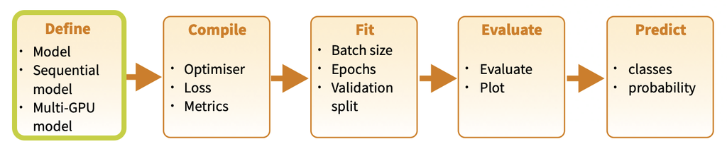

# Static computational graphs

A computational graph is a type of directed graph where：

- nodes: describe operations
  - operation node: operation
  - storage node: Variable
  - data node: PlaceHolder
- edges: represent the data (tensor) flowing between those operations
  - Tensor
  - SparseTensor

Building computational graphs requires three elements:

- `keras.Input()`: start model by define an Input object
  - `shape=()` have to be defined at input layers
- `layers`: chain layer calls to specify the model's forward pass
  - `shape=()` have to be defined at output layers
- `keras.Model()`: groups layers into an object with training and inference features
  - `inputs=[]`
  - `outputs=[]`

## API comparison

| Feature | sequential API | Functional API |
| --- | --- | --- |
| description | plain stack of layers | complex graph topologies |
| model/layers inputs | one | multiple |
| model/layers outputs | one | multiple |
| layer sharing | False | True |
| topology | linear | non-linear |
| special usage | - | residual connection, a multi-branch model |

Table: Sequential model vs Functional API

## keras.Sequential

```python
model = keras.Sequential()
model.add(keras.Input(shape=(4,)))
model.add(layers.Dense(2, activation="relu"))
```

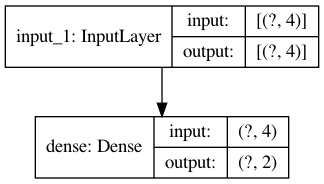

```python
keras.utils.plot_model(model, "multi_input_and_output_model.png", show_shapes=True)
```

## Functional API

```python
main_input = keras.Input(shape=(4,), name="main_input")
aux_input = keras.Input(shape=(2,), name="aux_input")

x = layers.concatenate([main_input, aux_input])

main_output = layers.Dense(1, name="main_output")(x)
aux_output = layers.Dense(2, name="aux_output")(x)

model = keras.Model(
    inputs=[main_input, aux_input],
    outputs=[main_output, aux_output],
)
```

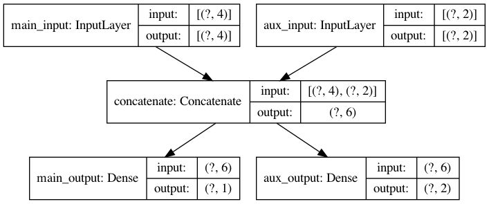

```python
keras.utils.plot_model(model, "multi_input_and_output_model.png", show_shapes=True)
```

# Layer

Layers are functions with a known mathematical structure that can be reused and have trainable variables.

class `layer` has `def __call__(self, inputs, **kwargs):`, so it is callable and be written into double brackets.

```
x = layers.Dense(64, activation='relu')(x)
equvalent to:
fc = Dense(64, activation='relu')
x = fc(x)
```

## Input shape

Since the input shape is the only one you need to define, Keras will demand it in the first layer. But in this definition, Keras ignores the first dimension, which is the batch size. Your model should be able to deal with any batch size, so you define only the other dimensions:

- when defining the input shape, ignore the batch size: `input_shape=(50,50,3)`
- When doing operations directly on tensors, the shape will be again `(30,50,50,3)`
- when printing the model summary, it will show `(None,50,50,3)` for `input_shape=(50,50,3)`:
  - The first dimension is the batch size, it's None because it can vary depending on how many examples you give for training. If you defined the batch size explicitly, then the number you defined will appear instead of `None`

Each type of layer requires the input with a certain number of dimensions:

- Dense layers: `(batch_size, input_size)` or `(batch_size, optional,...,optional, input_size)`
- 2D convolutional layers:
  - if using channels_last: `(batch_size, imageside1, imageside2, channels)`
  - if using channels_first: `(batch_size, channels, imageside1, imageside2)`
- 1D convolutions and recurrent layers: `(batch_size, sequence_length, features)`

reference: https://stackoverflow.com/questions/44747343/keras-input-explanation-input-shape-units-batch-size-dim-etc

## Module comparison

Two modules in Tensorflow provides layers API with different levels. Using `conv2d` as example for comparison:

- `tf.nn`: Wrappers for primitive Neural Net (NN) Operations. This lower level API is there for people with special needs, or who wishes to keep a finer control of what is going on
  - `tf.nn.conv2d`: has to manually declare weights, biases, regularization, activation
- `tf.keras.layers`: high level wrapper built upon tf.nn. This higher level API is to provide functions that greatly simplify the design of the most common neural nets.
  - `tf.keras.layers.conv2d`: a single line of code to create a convolutional layer, with default setting for weights, biases, regularization, activation.

reference: https://stackoverflow.com/questions/45172725/tensorflow-why-are-there-so-many-similar-or-even-duplicate-functions-in-tf-nn

## Layer list

### CORE LAYERS

layer

description

illustration

tf.keras.layers.InputLayer

Layer to be used as an entry point into a Network (a graph of layers)

tf.keras.layers.Dense

regular densely-connected NN layer

tf.keras.layers.Activation

Apply an activation function to an output

tf.keras.layers.Dropout

Applies Dropoutto the input

tf.keras.layers.Reshape

Reshapes an output to a certain shape

tf.keras.layers.Permute

Permute the dimensions of an input according to a given pattern

tf.keras.layers.RepeatVector

Repeats the input n times

tf.keras.layers.Lambda

Wraps arbitrary expression as a layer

tf.keras.layers.ActivityRegularization

Layer that applies an update to the cost function based input activity

tf.keras.layers.Masking

Masks a sequence by using a mask value to skip timesteps

tf.keras.layers.Flatten

Flattens an input

tf.keras.layers.Concatenate

concatenates a list of inputs.

### CONVOLUTIONAL LAYERS

layer

description

illustration

tf.keras.layers.Conv1D

1D, e.g.temporal convolution

tf.keras.layers.Conv1DTranspose

Transposed convolution layer (sometimes called Deconvolution)

tf.keras.layers.Conv2D

2D, e.g. spatial convolution over images

tf.keras.layers.Conv2DTranspose

Transposed 2D (deconvolution)

tf.keras.layers.Conv3D

3D, e.g. spatial convolution over volumes

tf.keras.layers.Conv3DTranspose

Transposed 3D (deconvolution)

tf.keras.layers.ConvLSTM2D

Convolutional LSTM

tf.keras.layers.SeparableConv1D  
tf.keras.layers.SeparableConv2D

Depthwise separable 2D

tf.keras.layers.UpSampling1D  
tf.keras.layers.UpSampling2D  
tf.keras.layers.UpSampling3D

Upsampling layer

tf.keras.layers.ZeroPadding1D  
tf.keras.layers.ZeroPadding2D  
tf.keras.layers.ZeroPadding3D

Zero-padding layer

tf.keras.layers.Cropping1D  
tf.keras.layers.Cropping2D  
tf.keras.layers.Cropping3D

Cropping layer

### POOLING LAYERS

[output not shown]

### ACTIVATION LAYERS

| layer | description |
| --- | --- |
| tf.keras.layers.Activation(object, activation) | Apply an activation function to an output |
| tf.keras.layers.LeakyReLU | Leaky version of a rectified linear unit |
| tf.keras.layers.PReLU | Parametric rectified linear unit |
| tf.keras.layers.ThresholdedReLU | Thresholded rectified linear unit |
| tf.keras.layers.ELU | Exponential linear unit |
| tf.keras.layers.Softmax | Softmax activation function |

### DROPOUT LAYERS

| layer | description |
| --- | --- |
| tf.keras.layers.Dropout | Applies dropout to the input |
| tf.keras.layers.SpatialDropout1D tf.keras.layers.SpatialDropout2D tf.keras.layers.SpatialDropout3D | Spatial 1D to 3D version of dropout |

### RECURRENT LAYERS

| layer | description |
| --- | --- |
| tf.keras.layers.SimpleRNN | Fully-connected RNN where the output is to be fed back to input |
| tf.keras.layers.GRU | Gated recurrent unit - Cho et al |
| tf.keras.layers.LSTM | Long-Short Term Memory unit - Hochreiter 1997 |
| tf.keras.layers.ConvLSTM1D tf.keras.layers.ConvLSTM2D tf.keras.layers.ConvLSTM3D | Similar to an LSTM layer, but the input transformations and recurrent transformations are both convolutional. |

### LOCALLY CONNECTED LAYERS

| layer | description |
| --- | --- |
| tf.keras.layers.LocallyConnected1D tf.keras.layers.LocallyConnected2D | Similar to convolution, but weights are not shared, i.e. different filters for each patch |

### ATTENTION LAYER

| layer | description |
| --- | --- |
| tf.keras.layers.Dot | Layer that computes a dot product between samples in two tensors. |
| tf.linalg.matmul | Multiplies matrix a by matrix b, producing a * b |
| tf.keras.layers.Attention | Dot-product attention layer, a.k.a. Luong-style attention |
| tf.keras.layers.AdditiveAttention | Additive attention layer, a.k.a. Bahdanau-style attention. |
| tf.keras.layers.MultiHeadAttention | MultiHeadAttention layer |

### ARITHMETIC

| layer | description |
| --- | --- |
| tf.keras.layers.Add | Layer that adds (element-wise) a list of inputs. |
| tf.keras.layers.Subtract | Layer that subtracts (element-wise) two inputs |
| tf.keras.layers.Multiply | Layer that multiplies (element-wise) a list of inputs. |
| tf.keras.layers.Maximum | Layer that computes the maximum (element-wise) a list of inputs |
| tf.keras.layers.Minimum | Layer that computes the minimum (element-wise) a list of inputs |

| function | description |
| --- | --- |
| tf.keras.layers.add | function that adds (element-wise) a list of inputs. |
| tf.keras.layers.subtract | function that subtracts (element-wise) two inputs |
| tf.keras.layers.multiply | function that multiplies (element-wise) a list of inputs. |
| tf.keras.layers.maximum | function that computes the maximum (element-wise) a list of inputs |
| tf.keras.layers.minimum | function that computes the minimum (element-wise) a list of inputs |

### DIMENTION REDUCTION

| layer | description |
| --- | --- |
| tf.math.reduce_sum | Computes the sum of elements across dimensions of a tensor. |
| tf.math.reduce_prod | Computes tf.math.multiply of elements across dimensions of a tensor. |
| tf.math.reduce_mean | Computes the mean of elements across dimensions of a tensor. |
| tf.math.reduce_max | Computes tf.math.maximum of elements across dimensions of a tensor. |
| tf.math.reduce_min | Computes the tf.math.minimum of elements across dimensions of a tensor. |
| tf.math.reduce_variance | Computes the variance of elements across dimensions of a tensor. |
| tf.math.reduce_std | Computes the standard deviation of elements across dimensions of a tensor. |